# The Virtual Brain Ontology

The Virtual Brain Ontology

# One specification for a whole *brain-network* simulation.

From one typed, ontology-grounded spec, `tvbo` compiles runnable code across many backends and a methods report — and grounds every parameter in a knowledge graph. Studies re-run without drift; models compare even when they share no notation.

[figure not shown]

Get started → Explore the platform →

The five steps this documentation follows

1. 1

### Explore

   Find curated models, networks and published studies in the knowledge base.
2. 2

### Specify

   Declare the experiment — dynamics, network, observations, figures.
3. 3

### Generate

   Compile it to backend-native code, plots and a study directory.
4. 4

### Run

   Execute on a laptop or a cluster, and read the result back.
5. 5

### Share

   Publish to the platform, and export results as BIDS.

3 From one source →

- TVB
- JAX
- Julia
- C / CUDA
- Brian2
- PyRates
- NeuroML

Each step opens an overview of the pages beneath it, and every page carries the number of the step it belongs to, in the top-left corner.

[figure not shown]

One specification, two payoffs — TVB-O compiles code and a methods report across backends (reproducible) and grounds every entity in a knowledge graph (comparable).

### Python Software

The `tvbo` library — specify models, generate code across backends, and run simulations from Python.

API reference →

### Platform

The hosted web app — browse models & networks, build experiments, and export, with no install.

Open the app ↗

### Data Model

The typed metadata schema behind every spec — classes, fields, and constraints.

Explore the schema →

## A first simulation

Install it, then run a whole brain. What a region does, the connectome the regions sit on, and how the result is drawn are one document. This page runs that document and shows what it produced; it contains no plotting code of its own.

```python
from tvbo import SimulationStudy

study = SimulationStudy.from_file("examples/first-simulation/study.yaml")
result = study.run(root="_build/first-simulation")
result
```

[output not shown]

```
wrote /Users/leonmartin_bih/tools/tvbo/docs/_build/first-simulation/docs/figures/first_simulation.gif (24 frames)
```

```
INFO [tvbo.cli] wrote /Users/leonmartin_bih/tools/tvbo/docs/_build/first-simulation/docs/figures/first_simulation.gif
INFO [tvbo.cli] wrote /Users/leonmartin_bih/tools/tvbo/docs/_build/first-simulation/docs/figures/scripts/plot_first_simulation.py
INFO [tvbo.cli] wrote /Users/leonmartin_bih/tools/tvbo/docs/_build/first-simulation/docs/figures/first_simulation.caption.qmd
```

```
wrote /Users/leonmartin_bih/tools/tvbo/docs/_build/first-simulation/docs/figures/first_simulation.png
```

```
StudyResult(experiments=['exp-1'], figures=['first_simulation'], results_root='_build/first-simulation/derivatives/tvbo')
```

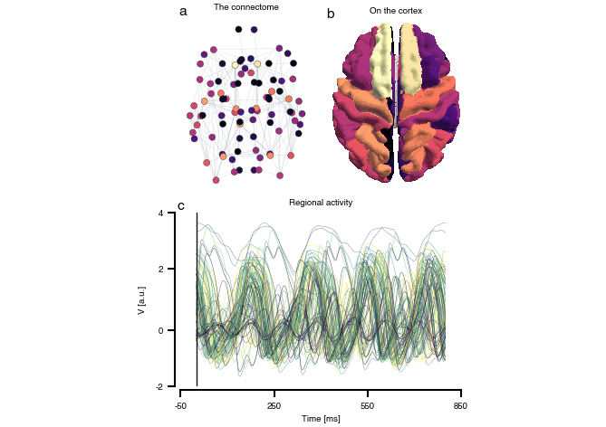

Figure 1

Three panels of one movie, and not a line of plotting code behind them. **(a)** is the connectome the model actually ran on, its nodes coloured by the state they are in. **(b)** is that same state on the cortical surface, placed by region *name* rather than by array position, so a value cannot land on its neighbour. **(c)** is every region’s course, with a cursor marking the instant the other two panels show.

### The document behind it

Both halves below are read out of the file the cell above just ran, so this page cannot drift away from what it showed you.

**The experiment**

```yaml
# The landing page's first simulation, run by `tvbo run study.yaml` or by `SimulationStudy.from_file(...).run()`. Its directory is the study root.
tvbo_class: tvbo:SimulationStudy

citekey: FirstSimulation
title: "A first whole-brain simulation"
label: "Eighty-seven regions on a structural connectome, coupled through their tract lengths"
description: >-
  A Generic2dOscillator in its limit-cycle regime on the Desikan-Killiany connectome, coupled linearly through the tract lengths so regions oscillate at a phase lag set by how far apart they are. The figure it declares is one movie: the state on the graph, the same state on the cortical surface, and every region's course with a cursor on the instant the other two panels show.

experiments:
    - id: 1
      label: "A whole-brain simulation"
      dynamics:
          name: Generic2dOscillator
          iri: tvbo:Generic2dOscillator
          # a = 2.0 is TVB's own limit-cycle setting for this model; the rest of the curated set stands.
          parameters: {a: {value: 2.0}}
      network:
          iri: tvbo:DesikanKilliany
          transforms:
              - name: weight
                equation: {rhs: "weight / mean(weight[weight > 0])"}
          coupling:
              c_glob:
                  iri: tvbo:Linear
                  delayed: true
                  incoming_states: [V]
                  parameters: {a: {value: 0.05}}
      integration: {method: Heun, step_size: 0.1, duration: 800.0, transient_time: 300.0}
```

**The figure**

```yaml
figures:
    - name: first_simulation
      label: "A first whole-brain simulation"
      layout: "ab/cc"
      width: 170.0
      height: 120.0
      font_size: 7.0
      dpi: 100
      animation: {over: time, frames: 24, fps: 10, format: gif, still: 12}
      panels:
          a:
              kind: network
              label: "The connectome"
              layers:
                  - used: {experiment: 1, output: integration, sel: {variable: V}}
              opts:
                  network: tvbo:DesikanKilliany
                  projection: axial
                  cmap: magma
          b:
              kind: surface
              label: "On the cortex"
              layers:
                  - used: {experiment: 1, output: integration, sel: {variable: V}}
              opts:
                  atlas: tvbo:atlas/DesikanKilliany
                  template: fsaverage
                  hemi: both
                  view: dorsal
                  cmap: magma
                  symmetric: false
          c:
              kind: cartesian
              label: "Regional activity"
              layers:
                  - used: {experiment: 1, output: integration, sel: {variable: V}}
                    mark: line
                    frame: static
                    encoding: {x: time}
                    style: {opts: {linewidth: 0.4, alpha: 0.6}}
                  - used: {experiment: 1, output: integration, sel: {variable: V}}
                    mark: rule
                    frame: cursor
                    encoding: {x: time}
                    style: {color: "#111111", opts: {linewidth: 1.0}}
              opts:
                  xlabel: "Time [ms]"
                  ylabel: "V [a.u.]"
```

A figure in TVB-O is data, not a script: a mosaic of panels whose layers bind a field of the result container to a visual channel. The binding that says *which data* is typed `prov:used`, so declaring where a mark’s numbers come from **is** the provenance record. See Specify a figure.

## The same specification, three ways to reach it

The recipe above is a file, and a file is only one of the places a specification can live. These are alternatives, not steps.

**From the shell**

```bash
tvbo run examples/first-simulation/study.yaml     # run it, and render the figures it declares
tvbo export jax examples/first-simulation/study.yaml -o solve.py
```

**From Python**

```python
from tvbo import SimulationStudy

result = SimulationStudy.from_file("examples/first-simulation/study.yaml").run()
result["exp-1"].integration.sel(node="ctx-lh-precentral")
```

**Written inline**

```python
from tvbo import SimulationExperiment

exp = SimulationExperiment(
    label="A whole-brain simulation",
    dynamics={"iri": "tvbo:Generic2dOscillator", "parameters": {"a": {"value": 2.0}}},
    network={
        "iri": "tvbo:DesikanKilliany",
        "coupling": {"c_glob": {"iri": "tvbo:Linear", "delayed": True, "incoming_states": ["V"]}},
    },
    integration={"method": "Heun", "step_size": 0.1, "duration": 800.0},
)
result = exp.run()
```

## Where to start

Getting started

New to TVB-O: one equation to a whole brain, in a single sitting.

The SimulationExperiment

Want the spec: every top-level field, and which ones are required.

Linked experiments in a SimulationStudy

Replicating a paper: many experiments, one study, shared figures.

Interoperability

Coming from another tool: TVB, PyRates, NeuroML and the Julia backends.